# Pipedrive test task

Siim Põldre

5 5 2021

TRY TO AUTOMAICALLY ACCESS FILE FROM KAGGLE.

1)Data tranformations 2)General descriptives 3)Logistic regression on raw data 4)Clustering and cluster analsys (how clusters differ + logistic regression using clusters with baseline) 5)XGBoost and feature analysis

I chose a dataset from kaggle that deals with a broadband companies churn. The dataset is from january 2020. I chose this specific dataset firstly because of its content. It is a subscription based service that offers several packages(Bandwidth) and has to deal with churn. This is similar to the types of data Pipedrive deals with and churn is a problem in any company. Secondly the features have nice metadata so i understand more clearly what i am looking at. The inconvenience with this dataset is that each customer has a row for each month they are a customer (~500k rows) but for most of the analysis i am planning to do it is better to have the data in a format where each customer has one row. For this i have to transform the whole dataset.

```r
churn_tr <- read.csv("bbs_cust_base_scfy_20200210.csv", header = TRUE)
```

There are some missing values but for two features the percentages are very low (under 1%) so they are not probably a major cause for concern when we remove these lines.

```r
Puuduvad <- churn_tr %>%
  summarise_all(funs(sum(is.na(.)))) %>%
  pivot_longer(everything(), names_to = "Feature", values_to = "Missing")
Puuduvad %>%
  mutate(Prop.missing = round(`Missing`/nrow(churn_tr),4)) %>%
  filter(Missing > 0) %>%
  arrange(., desc(Missing)) %>%
  kbl() %>%
  kable_styling()
```

| Feature | Missing | Prop.missing |
| --- | --- | --- |
| contract_month | 1937 | 0.0038 |
| ce_expiry | 1937 | 0.0038 |

```r
churn_tr <- churn_tr %>%
  drop_na()
```

There are:  
- 14 categorical variables  
- 5 integers (more caution in interpreting descriptives as numeric) - 1 numeric variables

The data has ~510k rows and 20 columns. Secured revenue is the only numeric/float variable. I will treat image and contract month as categorical variables (altho they are ordinal). Image because it is actually a date variable about billing month and contract month because it has a more categorical character being a contract type or category.

```python
r.churn_tr.info()
```

```
## <class 'pandas.core.frame.DataFrame'>
## RangeIndex: 508188 entries, 0 to 508187
## Data columns (total 20 columns):
##  #   Column              Non-Null Count   Dtype
## ---  ------              --------------   -----
##  0   image               508188 non-null  int32
##  1   newacct_no          508188 non-null  object
##  2   line_stat           508188 non-null  object
##  3   bill_cycl           508188 non-null  int32
##  4   serv_type           508188 non-null  object
##  5   serv_code           508188 non-null  object
##  6   tenure              508188 non-null  int32
##  7   effc_strt_date      508188 non-null  object
##  8   effc_end_date       508188 non-null  object
##  9   contract_month      508188 non-null  int32
##  10  ce_expiry           508188 non-null  int32
##  11  secured_revenue     508188 non-null  float64
##  12  bandwidth           508188 non-null  object
##  13  term_reas_code      508188 non-null  object
##  14  term_reas_desc      508188 non-null  object
##  15  complaint_cnt       508188 non-null  object
##  16  with_phone_service  508188 non-null  object
##  17  churn               508188 non-null  object
##  18  current_mth_churn   508188 non-null  object
##  19  X                   508188 non-null  object
## dtypes: float64(1), int32(5), object(14)
## memory usage: 67.9+ MB
```

Looking at variables to see if some have 0 variance to remove them: 1) bill_cycl has no variance so we don’t need that variable (labeled as ignorable in the data source too) 2)serv_type also has only one value(BBS)

```r
churn_tr %>%
  lapply(unique) %>%
  lapply(length)
```

```
## $image
## [1] 24
##
## $newacct_no
## [1] 27405
##
## $line_stat
## [1] 3
##
## $bill_cycl
## [1] 1
##
## $serv_type
## [1] 1
##
## $serv_code
## [1] 287
##
## $tenure
## [1] 226
##
## $effc_strt_date
## [1] 2085
##
## $effc_end_date
## [1] 2348
##
## $contract_month
## [1] 56
##
## $ce_expiry
## [1] 180
##
## $secured_revenue
## [1] 10329
##
## $bandwidth
## [1] 9
##
## $term_reas_code
## [1] 27
##
## $term_reas_desc
## [1] 27
##
## $complaint_cnt
## [1] 9
##
## $with_phone_service
## [1] 3
##
## $churn
## [1] 2
##
## $current_mth_churn
## [1] 2
##
## $X
## [1] 2
```

```r
churn_tr <- churn_tr %>%
  select(-bill_cycl & -serv_type & -line_stat) #getting rid of variable with no variance
```

```r
churn_oc <- churn_tr %>%
  filter(complaint_cnt %in% c("0","1", "2", "3", "4", "5", "6", "7")) %>%
  mutate(complaint_cnt = as.numeric(complaint_cnt)) %>%
  group_by(newacct_no) %>%
  summarise(churn = first(churn), #is churned or not
            term_read_code = last(term_reas_code), #termination reason code
            term_reas_desc = last(term_reas_desc), #termination reason description
            tenure = (max(tenure)-min(tenure)), #Tenure
            contract_month = first(contract_month), #contract length
            ce_expiry = first(ce_expiry), #ifference between contract and jan 2020
            secured_revenue = mean(secured_revenue), #average revenue
            last_band = last(bandwidth), #last known bandwidth
            complaint_avg = mean(complaint_cnt), #average complaints per month
            phone_serv = last(with_phone_service)) %>% #Last info about using phone service
  ungroup() %>%
  select(-newacct_no) #Getting rid of customer identifier
```

```python
r.churn_oc.info()
```

```
## <class 'pandas.core.frame.DataFrame'>
## RangeIndex: 27405 entries, 0 to 27404
## Data columns (total 10 columns):
##  #   Column           Non-Null Count  Dtype
## ---  ------           --------------  -----
##  0   churn            27405 non-null  object
##  1   term_read_code   27405 non-null  object
##  2   term_reas_desc   27405 non-null  object
##  3   tenure           27405 non-null  int32
##  4   contract_month   27405 non-null  int32
##  5   ce_expiry        27405 non-null  int32
##  6   secured_revenue  27405 non-null  float64
##  7   last_band        27405 non-null  object
##  8   complaint_avg    27405 non-null  float64
##  9   phone_serv       27405 non-null  object
## dtypes: float64(2), int32(3), object(5)
## memory usage: 1.8+ MB
```

Percentage of people churned is a lot lower so a lot of class imbalance.

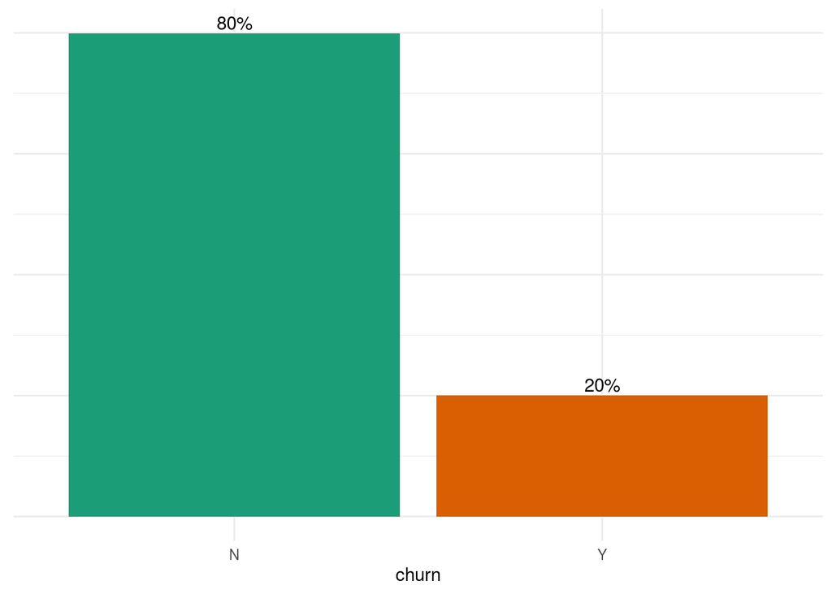

```r
churn_oc %>%
  ggplot(aes(x = churn, fill = churn)) +
  geom_bar(aes(y = (..count..)/sum(..count..))) +
  scale_y_continuous(labels = percent) +
  geom_text(aes(y = ((..count..)/sum(..count..)), label = scales::percent((..count..)/sum(..count..))), stat = "count", vjust = -0.25) +
  theme_minimal()+
  theme(axis.text.y=element_blank(),
        axis.ticks=element_blank(),
        axis.title.y=element_blank(),
        legend.position = "none")+
  scale_fill_brewer(palette = "Dark2")
```

```r
churn_oc %>%
  select_if(~class(.) != 'character') %>%
  describe(., IQR = TRUE,quant = c(.25, .75)) %>%
  kbl() %>%
  kable_styling()
```

|  | vars | n | mean | sd | median | trimmed | mad | min | max | range | skew | kurtosis | se | IQR | Q0.25 | Q0.75 |
| --- | --- | --- | --- | --- | --- | --- | --- | --- | --- | --- | --- | --- | --- | --- | --- | --- |
| tenure | 1 | 27405 | 17.5440613 | 7.454044 | 23 | 18.788187 | 0.0000 | 0.00 | 23.00 | 23.00 | -1.030771 | -0.4249013 | 0.0450274 | 11.0000 | 12.0000 | 23.0000 |
| contract_month | 2 | 27405 | 24.8804598 | 5.808631 | 24 | 24.044971 | 0.0000 | 0.00 | 120.00 | 120.00 | 6.519404 | 101.2125154 | 0.0350880 | 0.0000 | 24.0000 | 24.0000 |
| ce_expiry | 3 | 27405 | 5.7987229 | 16.157107 | 9 | 7.657879 | 11.8608 | -175.00 | 115.00 | 290.00 | -1.551307 | 9.4285845 | 0.0975997 | 15.0000 | 1.0000 | 16.0000 |
| secured_revenue | 4 | 27405 | 550.7780122 | 1509.494744 | 226 | 293.741846 | 127.5036 | -385.22 | 42611.07 | 42996.29 | 12.661722 | 245.7089777 | 9.1183593 | 243.2017 | 166.1317 | 409.3333 |
| complaint_avg | 5 | 27405 | 0.0274335 | 0.156793 | 0 | 0.000000 | 0.0000 | 0.00 | 5.00 | 5.00 | 9.879005 | 160.1003735 | 0.0009471 | 0.0000 | 0.0000 | 0.0000 |

From visual assessment we can see that: 1)people not using a phone service are more likely to churn 2)people using lower bandwidth packages are more likely to churn

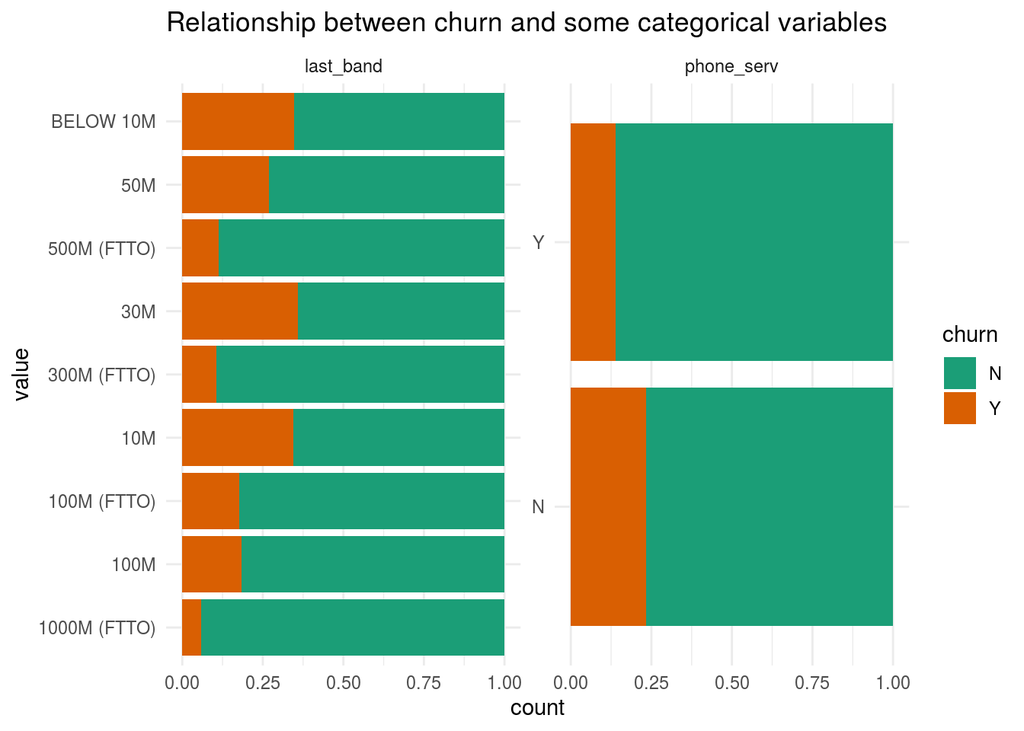

```r
churn_oc %>%
  select(-term_read_code, -term_reas_desc) %>%  #uninformative variables in this case
  select_if(~class(.) == 'character') %>%
  pivot_longer(!churn, names_to = c("feature"), values_to = c("value")) %>%
  ggplot(aes(x = value, fill = churn))+
  geom_bar(position = "fill") +
  theme_minimal()+
  coord_flip()+
  scale_fill_brewer(palette = "Dark2")+
  facet_wrap(~feature, scales = "free")+
  labs(title = "Relationship between churn and some categorical variables")
```

```python
r.churn_oc.info()
```

```
## <class 'pandas.core.frame.DataFrame'>
## RangeIndex: 27405 entries, 0 to 27404
## Data columns (total 10 columns):
##  #   Column           Non-Null Count  Dtype
## ---  ------           --------------  -----
##  0   churn            27405 non-null  object
##  1   term_read_code   27405 non-null  object
##  2   term_reas_desc   27405 non-null  object
##  3   tenure           27405 non-null  int32
##  4   contract_month   27405 non-null  int32
##  5   ce_expiry        27405 non-null  int32
##  6   secured_revenue  27405 non-null  float64
##  7   last_band        27405 non-null  object
##  8   complaint_avg    27405 non-null  float64
##  9   phone_serv       27405 non-null  object
## dtypes: float64(2), int32(3), object(5)
## memory usage: 1.8+ MB
```

Here ill build an easily interpretable logistic regression model to look at main effects for variables

```r
churn_oc_lr <- churn_oc %>%
  mutate(churn = recode(churn, Y = 1, N = 0))

churn_log <- glm(churn ~ tenure + last_band + contract_month + ce_expiry + secured_revenue + complaint_avg + phone_serv, family=binomial(link="logit"), data=churn_oc_lr)
summary(churn_log)
```

```
##
## Call:
## glm(formula = churn ~ tenure + last_band + contract_month + ce_expiry +
##     secured_revenue + complaint_avg + phone_serv, family = binomial(link = "logit"),
##     data = churn_oc_lr)
##
## Deviance Residuals:
##     Min       1Q   Median       3Q      Max
## -7.3376  -0.3076  -0.1337  -0.0432   3.5174
##
## Coefficients:
##                        Estimate Std. Error z value Pr(>|z|)
## (Intercept)          -3.576e-01  2.183e-01  -1.638 0.101386
## tenure               -1.534e-01  5.273e-03 -29.092  < 2e-16 ***
## last_band100M         1.605e+00  1.506e-01  10.656  < 2e-16 ***
## last_band100M (FTTO)  1.500e+00  1.579e-01   9.499  < 2e-16 ***
## last_band10M          1.869e+00  1.692e-01  11.047  < 2e-16 ***
## last_band300M (FTTO)  1.101e+00  2.552e-01   4.314 1.60e-05 ***
## last_band30M          2.003e+00  1.751e-01  11.441  < 2e-16 ***
## last_band500M (FTTO)  1.441e+00  3.180e-01   4.532 5.85e-06 ***
## last_band50M          1.938e+00  5.180e-01   3.742 0.000183 ***
## last_bandBELOW 10M   -2.948e+00  5.204e-01  -5.666 1.46e-08 ***
## contract_month        8.857e-03  6.356e-03   1.394 0.163445
## ce_expiry            -2.155e-01  3.310e-03 -65.087  < 2e-16 ***
## secured_revenue       4.237e-05  1.772e-05   2.391 0.016782 *
## complaint_avg         2.190e-01  1.877e-01   1.167 0.243371
## phone_servY          -2.078e-01  6.694e-02  -3.104 0.001909 **
## ---
## Signif. codes:  0 '***' 0.001 '**' 0.01 '*' 0.05 '.' 0.1 ' ' 1
##
## (Dispersion parameter for binomial family taken to be 1)
##
##     Null deviance: 27474.1  on 27404  degrees of freedom
## Residual deviance:  8774.7  on 27390  degrees of freedom
## AIC: 8804.7
##
## Number of Fisher Scoring iterations: 7
```

```r
exp(coefficients(summary(churn_log)))
```

```
##                        Estimate Std. Error      z value Pr(>|z|)
## (Intercept)          0.69936568   1.243937 1.943353e-01 1.106704
## tenure               0.85779295   1.005287 2.319985e-13 1.000000
## last_band100M        4.97835039   1.162569 4.243513e+04 1.000000
## last_band100M (FTTO) 4.48235466   1.171075 1.335025e+04 1.000000
## last_band10M         6.48096350   1.184321 6.277594e+04 1.000000
## last_band300M (FTTO) 3.00670357   1.290687 7.474528e+01 1.000016
## last_band30M         7.41167973   1.191331 9.309363e+04 1.000000
## last_band500M (FTTO) 4.22565676   1.374412 9.290931e+01 1.000006
## last_band50M         6.94612242   1.678700 4.216230e+01 1.000183
## last_bandBELOW 10M   0.05243182   1.682628 3.462342e-03 1.000000
## contract_month       1.00889677   1.006376 4.029246e+00 1.177560
## ce_expiry            0.80617432   1.003316 5.408726e-29 1.000000
## secured_revenue      1.00004237   1.000018 1.092931e+01 1.016924
## complaint_avg        1.24480503   1.206479 3.211065e+00 1.275542
## phone_servY          0.81239184   1.069228 4.486841e-02 1.001911
```

```r
churn_km <- churn_oc %>%
  select(-term_read_code & -term_reas_desc & -churn) %>%
  mutate(last_band = as.numeric(as.factor(last_band))) %>%
  mutate(phone_serv = as.numeric(as.factor(phone_serv)))
```

```python
import numpy as np
import pandas as pd
from sklearn.preprocessing import scale
churn_km = pd.DataFrame(scale(r.churn_km), index = r.churn_km.index, columns = r.churn_km.columns)
```

```python
from sklearn.cluster import KMeans
modelk = KMeans(n_clusters=4)
modelk.fit(churn_km)
```

```
## KMeans(n_clusters=4)
```

```python
churn_km['kclusters'] = modelk.predict(churn_km)
```

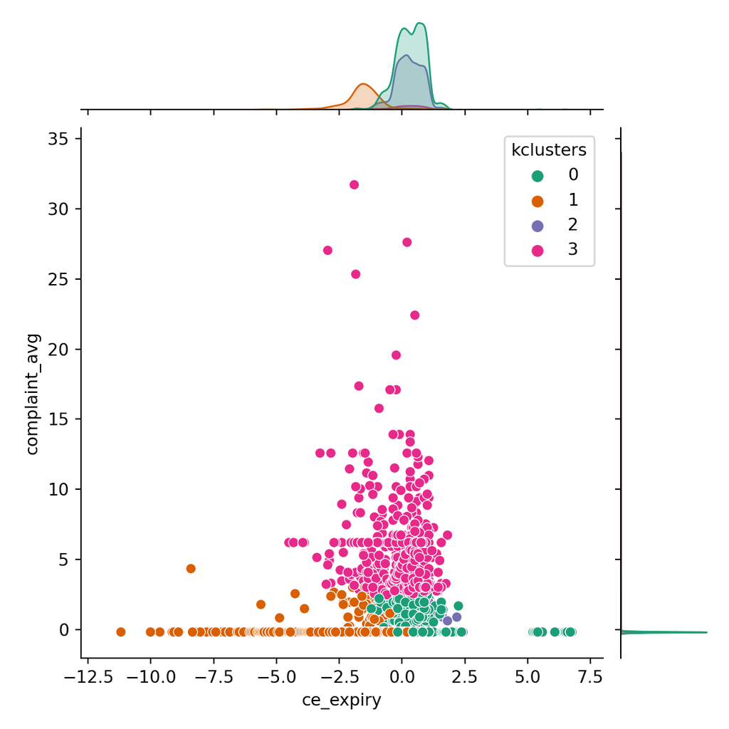

```python
import seaborn as sns
import matplotlib.pyplot as plt
fig, (ax1, ax2) = plt.subplots(1,2,figsize = (15,12))
sns.jointplot(x='tenure', y='secured_revenue', data=churn_km, hue='kclusters', palette='Dark2', ax = ax1)
sns.jointplot(x='ce_expiry', y='complaint_avg', data=churn_km, hue='kclusters', palette='Dark2', ax = ax2)
plt.show()
```